# Tugas MPDW Prak

Fatima Azzahra - G1401231036

2025-09-30

```r
library("lubridate")
library("readr")
library("readxl")
library("dplyr")
library("forecast")
```

```r
library("graphics")
library("TTR")
library("TSA")
library("ggplot2")
```

```r
library(tseries)
library(tsibble)
library(MASS)
```

# 1. Penyiapan Partisi Data

**Deskripsi**  
Dataset ini merupakan pencatatan berbagai macam komponen terkait cuaca dengan periode pencatatan per 10 menit dari tanggal 1 Januari 2020 sampai 31 Desember 2020. Analisis akan difokuskan pada peubah VPdef (Vapor Pressure Deficit).

Terkait cakupan analisis untuk tugas ini, akan dianalisis 100 baris pertama untuk peubah VPdef dengan cakupan periodenya yaitu 1 Januari 2020 pada menit ke-10 sampai 16:40.

```r
weather <- read_csv("D:\\TAHUN 3\\G1_MPDW\\cleaned_weather.csv")
View(weather)
str(weather)
```

```
## spc_tbl_ [52,696 × 21] (S3: spec_tbl_df/tbl_df/tbl/data.frame)
##  $ date    : chr [1:52696] "1/1/2020 0:10" "1/1/2020 0:20" "1/1/2020 0:30" "1/1/2020 0:40" ...
##  $ p       : num [1:52696] 1009 1009 1009 1009 1009 ...
##  $ T       : num [1:52696] 0.71 0.75 0.73 0.37 0.33 0.34 0.19 0.03 0.11 0.22 ...
##  $ Tpot    : num [1:52696] 273 273 273 273 273 ...
##  $ Tdew    : num [1:52696] -1.33 -1.44 -1.48 -1.64 -1.5 -1.54 -1.65 -1.7 -1.61 -1.62 ...
##  $ rh      : num [1:52696] 86.1 85.2 85.1 86.3 87.4 87.1 87.4 88.1 88.1 87.4 ...
##  $ VPmax   : num [1:52696] 6.43 6.45 6.44 6.27 6.26 6.26 6.19 6.12 6.16 6.2 ...
##  $ VPact   : num [1:52696] 5.54 5.49 5.48 5.41 5.47 5.45 5.41 5.39 5.43 5.42 ...
##  $ VPdef   : num [1:52696] 0.89 0.95 0.96 0.86 0.79 0.81 0.78 0.73 0.73 0.78 ...
##  $ sh      : num [1:52696] 3.42 3.39 3.39 3.35 3.38 3.37 3.34 3.33 3.35 3.35 ...
##  $ H2OC    : num [1:52696] 5.49 5.45 5.43 5.37 5.42 5.41 5.37 5.35 5.38 5.38 ...
##  $ rho     : num [1:52696] 1281 1280 1280 1282 1282 ...
##  $ wv      : num [1:52696] 1.02 0.43 0.61 1.11 0.49 0.63 0.88 1.05 0.9 0.62 ...
##  $ max. wv : num [1:52696] 1.6 0.84 1.48 1.48 1.4 1.32 1.28 1.64 1.72 1.04 ...
##  $ wd      : num [1:52696] 224 207 197 206 210 ...
##  $ rain    : num [1:52696] 0 0 0 0 0 0 0 0 0 0 ...
##  $ raining : num [1:52696] 0 0 0 0 0 0 0 0 0 0 ...
##  $ SWDR    : num [1:52696] 0 0 0 0 0 0 0 0 0 0 ...
##  $ PAR     : num [1:52696] 0 0 0 0 0 0 0 0 0 0 ...
##  $ max. PAR: num [1:52696] 0 0 0 0 0 0 0 0 0 0 ...
##  $ Tlog    : num [1:52696] 11.4 11.5 11.6 11.7 11.8 ...
##  - attr(*, "spec")=
##   .. cols(
##   ..   date = col_character(),
##   ..   p = col_double(),
##   ..   T = col_double(),
##   ..   Tpot = col_double(),
##   ..   Tdew = col_double(),
##   ..   rh = col_double(),
##   ..   VPmax = col_double(),
##   ..   VPact = col_double(),
##   ..   VPdef = col_double(),
##   ..   sh = col_double(),
##   ..   H2OC = col_double(),
##   ..   rho = col_double(),
##   ..   wv = col_double(),
##   ..   `max. wv` = col_double(),
##   ..   wd = col_double(),
##   ..   rain = col_double(),
##   ..   raining = col_double(),
##   ..   SWDR = col_double(),
##   ..   PAR = col_double(),
##   ..   `max. PAR` = col_double(),
##   ..   Tlog = col_double()
##   .. )
##  - attr(*, "problems")=<externalptr>
```

```r
# Change date format from chr to datetime
weather <- weather %>%
  mutate(datetime = mdy_hm(date))
# new dataframe with datetime and VPdef as respond variable
weather1 <- weather %>%
  dplyr::select(datetime, VPdef)
View(weather1)
str(weather1)
```

```
## tibble [52,696 × 2] (S3: tbl_df/tbl/data.frame)
##  $ datetime: POSIXct[1:52696], format: "2020-01-01 00:10:00" "2020-01-01 00:20:00" ...
##  $ VPdef   : num [1:52696] 0.89 0.95 0.96 0.86 0.79 0.81 0.78 0.73 0.73 0.78 ...
```

```r
# Check if there's missing value from time frequency per day
weather1 %>%
  group_by(date_only = as.Date(datetime)) %>%
  summarise(n_obs = n(), .groups = "drop") %>%
  filter(n_obs != 144)
```

```
## # A tibble: 4 × 2
##   date_only  n_obs
##   <date>     <int>
## 1 2020-01-01   143
## 2 2020-05-12   145
## 3 2020-05-29   135
## 4 2021-01-01     1
```

**Note: Missing Value and Duplicate**

```r
# Create the data subset
w1 <- weather1[1:100,]
head(w1, 20)
```

```
## # A tibble: 20 × 2
##    datetime            VPdef
##    <dttm>              <dbl>
##  1 2020-01-01 00:10:00  0.89
##  2 2020-01-01 00:20:00  0.95
##  3 2020-01-01 00:30:00  0.96
##  4 2020-01-01 00:40:00  0.86
##  5 2020-01-01 00:50:00  0.79
##  6 2020-01-01 01:00:00  0.81
##  7 2020-01-01 01:10:00  0.78
##  8 2020-01-01 01:20:00  0.73
##  9 2020-01-01 01:30:00  0.73
## 10 2020-01-01 01:40:00  0.78
## 11 2020-01-01 01:50:00  0.76
## 12 2020-01-01 02:00:00  0.66
## 13 2020-01-01 02:10:00  0.69
## 14 2020-01-01 02:20:00  0.72
## 15 2020-01-01 02:30:00  0.67
## 16 2020-01-01 02:40:00  0.72
## 17 2020-01-01 02:50:00  0.69
## 18 2020-01-01 03:00:00  0.7
## 19 2020-01-01 03:10:00  0.68
## 20 2020-01-01 03:20:00  0.62
```

```r
View(w1)
```

```r
# Change the data format to time series using 'ts' function
w1.ts <- ts(w1$VPdef)
summary(w1.ts)
```

```
##    Min. 1st Qu.  Median    Mean 3rd Qu.    Max.
##  0.2500  0.3475  0.7250  0.9988  1.5225  2.7000
```

```r
w1.ts
```

```
## Time Series:
## Start = 1
## End = 100
## Frequency = 1
##   [1] 0.89 0.95 0.96 0.86 0.79 0.81 0.78 0.73 0.73 0.78 0.76 0.66 0.69 0.72 0.67
##  [16] 0.72 0.69 0.70 0.68 0.62 0.54 0.53 0.52 0.52 0.48 0.47 0.52 0.42 0.41 0.36
##  [31] 0.40 0.34 0.32 0.32 0.30 0.30 0.29 0.27 0.26 0.25 0.25 0.26 0.29 0.31 0.30
##  [46] 0.29 0.28 0.27 0.27 0.27 0.26 0.30 0.31 0.29 0.30 0.32 0.35 0.38 0.38 0.47
##  [61] 0.69 0.77 0.78 0.75 0.80 0.75 0.82 0.84 0.89 0.90 0.97 1.15 1.27 1.33 1.50
##  [76] 1.59 1.82 1.93 1.95 2.01 2.34 2.36 2.45 2.33 2.18 2.27 2.40 2.39 2.58 2.70
##  [91] 2.52 2.43 2.59 2.64 2.62 2.36 2.12 2.01 1.98 1.94
```

**Note: Time Series Data Frequency**

Pada tahap eksplorasi awal ini digunakan frequency = 1 karena baru mengamati observasi dalam skala yang kecil.

# 2. Plot Time Series

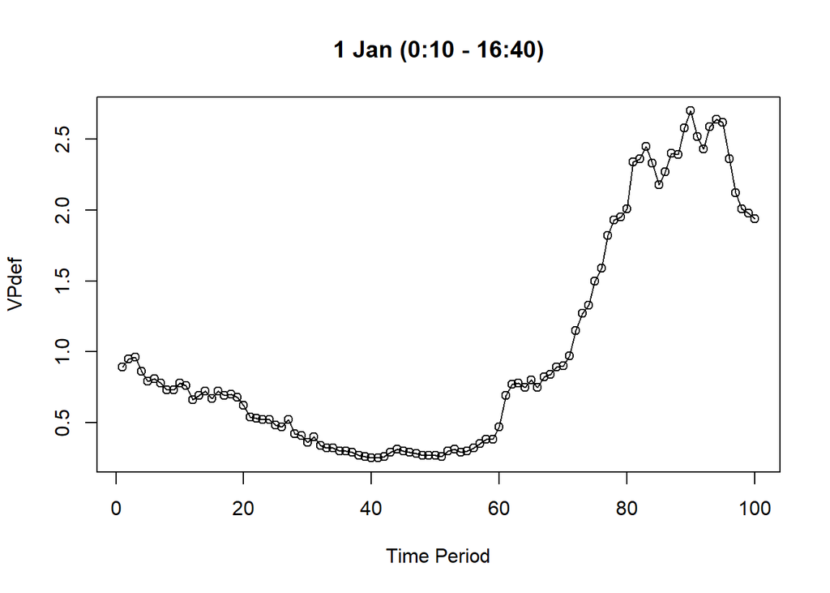

```r
ts.plot(w1.ts, xlab="Time Period", ylab="VPdef",
        main = "1 Jan (0:10 - 16:40)")
points(w1.ts)
```

Berdasarkan plot, data deret waktunya mengindikasikan **tidak stasioner pada rataam dan ragam**.

# 3. Plot ACF

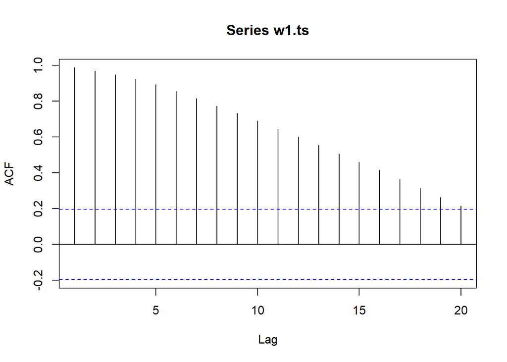

```r
acf(w1.ts)
```

Plot ACF menunjukkan penurunan yang lambat pada lag nya. Hal ini mengindikasikan data tak stasioner dalam rataan.

# 4. Uji ADF

```r
tseries::adf.test(w1.ts)
```

```
##
##  Augmented Dickey-Fuller Test
##
## data:  w1.ts
## Dickey-Fuller = -1.7408, Lag order = 4, p-value = 0.684
## alternative hypothesis: stationary
```

Berdasarkan uji ADF tersebut, didapat *p-value* lebih besar dari taraf nyata 5% sehingga Tak Tolak $H_0$ dan menandakan bahwa **data tidak stasioner dalam rataan**. Hal ini sesuai dengan hasil eksplorasi menggunakan plot time series dan plot ACF.

# 5. Plot Box-Cox

```r
index <- seq(1, 100)

# Uji Box-Cox
bc <- boxcox(
  w1.ts ~ index,
  lambda = seq(-2,2, by = 0.1)
)
```

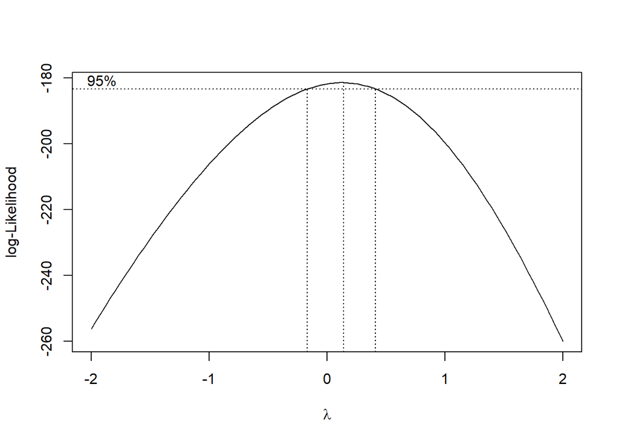

```r
# Nilai lambda optimum
lambda <- bc$x[which.max(bc$y)]
lambda
```

```
## [1] 0.1414141
```

```r
# Selang kepercayaan 95% untuk lambda
ci_lambda <- bc$x[bc$y > max(bc$y) - 0.5 * qchisq(0.95, 1)]

# Batas bawah dan batas atas
ci_lower <- min(ci_lambda)
ci_upper <- max(ci_lambda)

c(Batas_Bawah = ci_lower, Batas_Atas = ci_upper)
```

```
## Batas_Bawah  Batas_Atas
##  -0.1414141   0.3838384
```

Selang lambda tidak mengandung satu [-0.1414141, 0.3838384] sehingga **data tidak stasioner juga dalam ragam.**

# 6. Diferensiasi

Dalam analisis deret waktu, differencing merupakan salah satu prosedur transformasi yang digunakan untuk memperoleh sifat stasioneritas dalam rataan. Metode ini dilakukan dengan menghitung selisih nilai observasi antar periode sehingga pola tren atau ketidakstasioneran dalam rataan dapat dieliminasi.

Secara umum, pembedaan pertama ditulis sebagai:

$$\nabla Y_t = Y_t - Y_{t-1}$$

Jika tren linier masih tersisa/ belum stasioner, dapat dilakukan differencing kedua:
$$\nabla^2 Y_t = \nabla (\nabla Y_t) = Y_t - 2Y_{t-1} + Y_{t-2}$$

## Diferensiasi Pertama

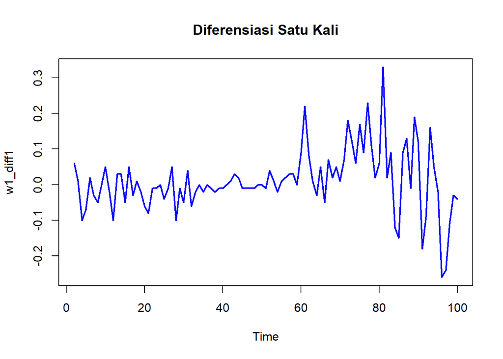

```r
# Differencing pertama pada postrend
w1_diff1 <- diff(w1.ts, differences = 1)

# Plot hasil differencing
ts.plot(w1_diff1,
        main = "Diferensiasi Satu Kali",
        col = "blue", lwd = 2)
```

**Plot ACF: Diferensiasi 1 Kali**

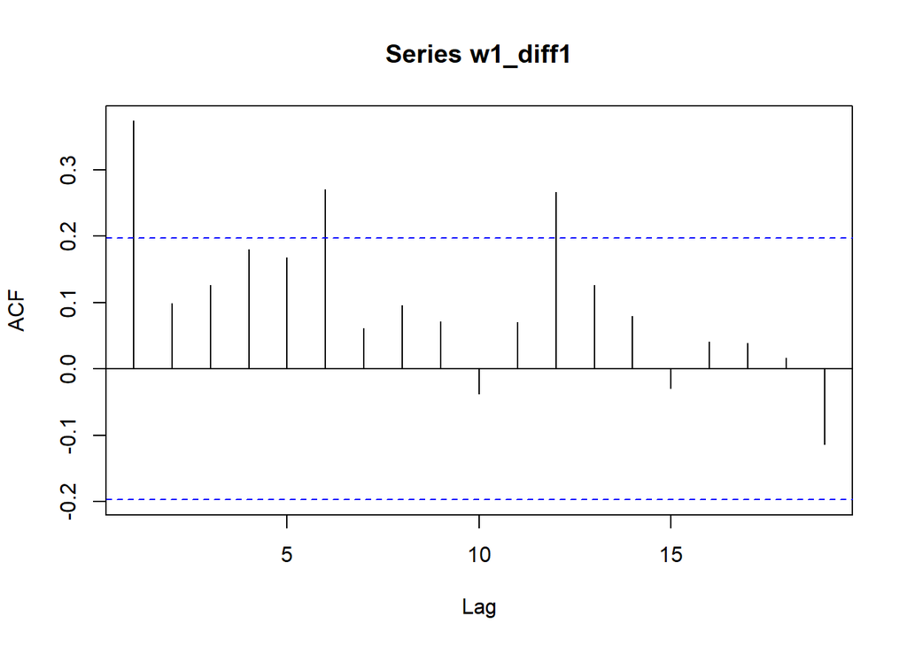

```r
acf(w1_diff1)
```

**Uji ADF: Diferensiasi 1 Kali**

```r
adf.test(w1_diff1)
```

```
##
##  Augmented Dickey-Fuller Test
##
## data:  w1_diff1
## Dickey-Fuller = -2.264, Lag order = 4, p-value = 0.4673
## alternative hypothesis: stationary
```

## Diferensiasi Kedua

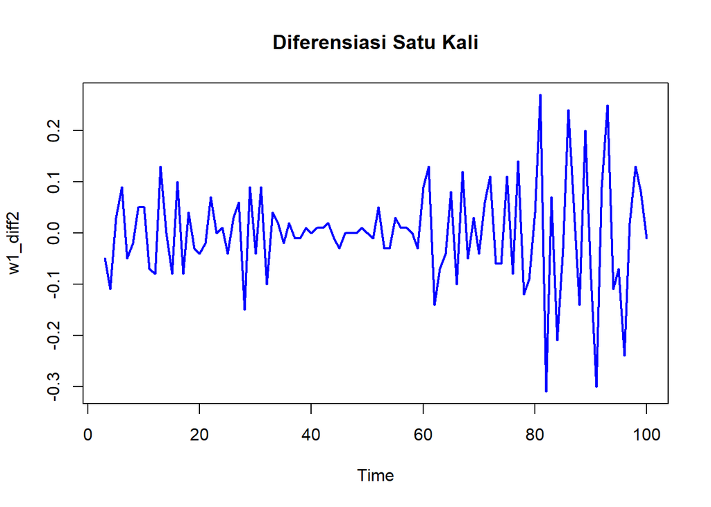

```r
# Differencing pertama pada postrend
w1_diff2 <- diff(w1.ts, differences = 2)

# Plot hasil differencing
ts.plot(w1_diff2,
        main = "Diferensiasi Satu Kali",
        col = "blue", lwd = 2)
```

**Plot ACF: Diferensiasi 2 Kali**

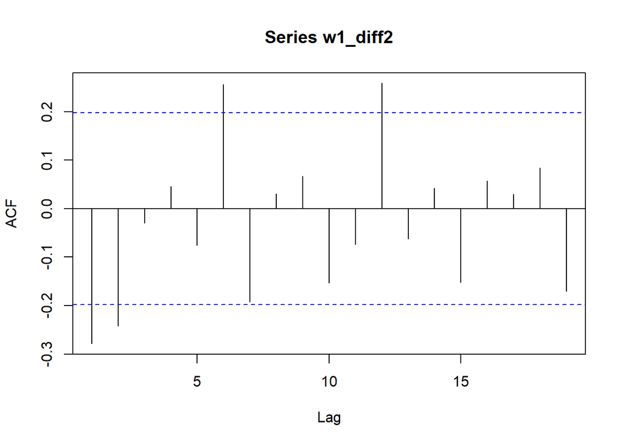

```r
acf(w1_diff2)
```

**Uji ADF: Diferensiasi 2 Kali**

```r
adf.test(w1_diff2)
```

```
##
##  Augmented Dickey-Fuller Test
##
## data:  w1_diff2
## Dickey-Fuller = -8.7341, Lag order = 4, p-value = 0.01
## alternative hypothesis: stationary
```

Berdasarkan uji ADF tersebut, didapat *p-value* sebesar 0.01 yang lebih kecil dari taraf nyata 5% sehingga Tolak $H_0$ dan menandakan bahwa **data sudah stasioner dalam rataan**.

## Plot Box-Cox

```r
index <- seq_along(w1_diff2)

# Uji Box-Cox
bc <- boxcox(
  (w1_diff2 - min(w1_diff2) + 1) ~ index,
  lambda = seq(-2, 2, by = 0.1)
)
```

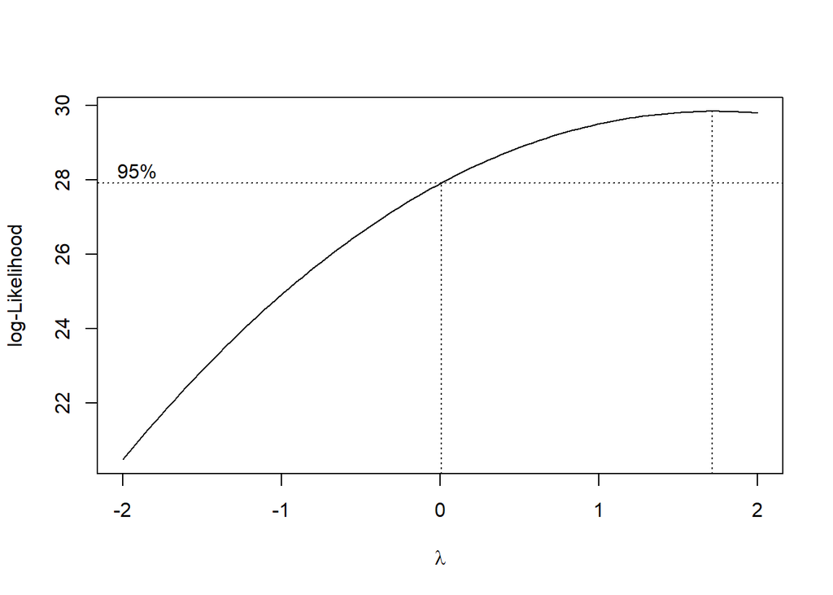

```r
# Nilai lambda optimum
lambda <- bc$x[which.max(bc$y)]
lambda
```

```
## [1] 1.717172
```

```r
# Selang kepercayaan 95% untuk lambda
ci_lambda <- bc$x[bc$y > max(bc$y) - 0.5 * qchisq(0.95, 1)]

# Batas bawah dan batas atas
ci_lower <- min(ci_lambda)
ci_upper <- max(ci_lambda)

c(Batas_Bawah = ci_lower, Batas_Atas = ci_upper)
```

```
## Batas_Bawah  Batas_Atas
##  0.02020202  2.00000000
```

Selang lambda mengandung satu [0.02020202, 2.00000000] sehingga **data stasioner dalam ragam** juga setelah diferensiasi 2 kali.

# 7. Simpulan

Data cuaca 100 baris pertama (peubah VPdef) memiliki plot deret waktu yang mengindikasikan pola yang tidak stasioner baik dalam rataan maupun ragam. Hal ini terbukti dengan plot ACF yang mengalami penurunan secara lambat pada lagnya, Uji ADF dengan p-value lebih besar dari 5% serta selang kepercayaan lambda pada plot Box-cox tidak mengandung nilai 1.

Setelah dilakukan diferensiasi 1 kali, stasioneritas rataan belum teratasi dan dilanjut percobaan dengan diferensiasi 2 kali. Hasilnya data stasioner dalam rataan berdasarkan nilai p-value uji ADF sebesar 0.01 yang lebih kecil dari 5% dan plot Box-cox yang mengandung nilai satu dalam selang kepercayaannya.